# Class 27: Assignment

John Doll

May 4, 2020

Source: J.J. Sepkoski, Jr., M.A. Rex (1974). “Distribution of Freshwater Mussels: Coastal Rivers as Biogeographic Islands,” Systematic Zoology, Vol. 23, #2, pp. 165-188.

```r
mussels <- read.table("mussels1.dat")
names(mussels) <- c("River", "Species", "Area",
                    "StepsToAC", "StepsToAP", "StepsToSV", "StepsToSL",
                    "Nitrate", "Residue", "Hydronium", "logArea")
head(mussels)
```

```
##          River Species Area StepsToAC StepsToAP StepsToSV StepsToSL Nitrate
## 1    Penobscot       9 8440        33        28        21         4     0.8
## 2     Kennebec       8 5960        32        27        20         5     0.4
## 3 Androscoggin       7 3510        31        26        19         6     0.6
## 4         Saco       6 1730        30        25        18         7     0.8
## 5     Merrimac      11 5020        29        24        17         8     2.6
## 6   Blackstone       8  425        26        21        14        11     8.4
##   Residue Hydronium logArea
## 1      57       4.0  9.0407
## 2      31       3.2  8.6928
## 3      65       2.5  8.1634
## 4      33       2.5  7.4559
## 5      78       6.3  8.5212
## 6     120      20.0  6.0521
```

*ANSWER THE FOLLOWING* with justification based on the output:

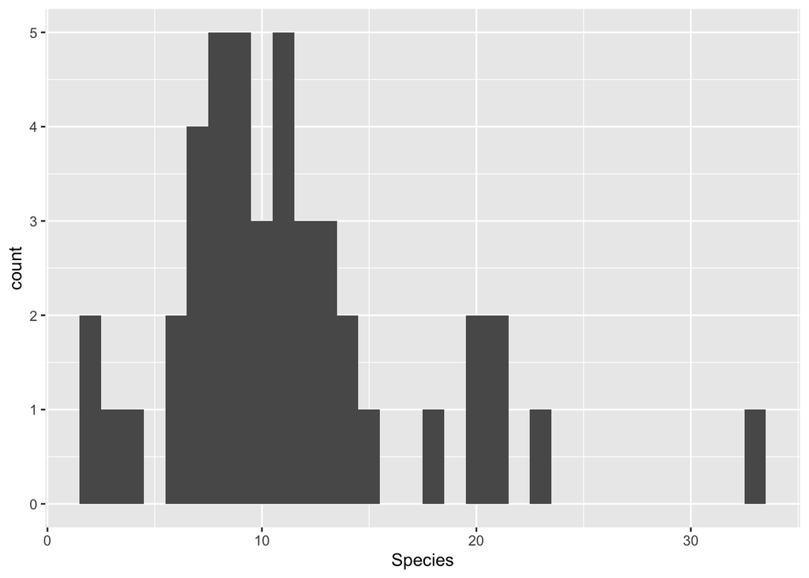

```r
ggplot(mussels, aes(x=Species) ) +
  geom_histogram(binwidth=1)
```

*ANSWER HERE: The shape looks like it is right skewed.*

**Question 2**. Fit a full Poisson regression model to predict the number of species from the four “stepping stones” variables, log area, and the nitrate, residue, and hydronium variables. Cite the AIC value for this full model.

```r
mussels.fit <- glm(Species ~ StepsToAC + StepsToAP + StepsToSV + StepsToSL + logArea + Nitrate + Residue + Hydronium, data = mussels, family = poisson)
summary(mussels.fit)
```

```
##
## Call:
## glm(formula = Species ~ StepsToAC + StepsToAP + StepsToSV + StepsToSL +
##     logArea + Nitrate + Residue + Hydronium, family = poisson,
##     data = mussels)
##
## Deviance Residuals:
##     Min       1Q   Median       3Q      Max
## -2.7738  -0.6296  -0.1117   0.5230   1.8758
##
## Coefficients:
##              Estimate Std. Error z value Pr(>|z|)
## (Intercept)  0.987518   1.144243   0.863  0.38812
## StepsToAC   -0.016641   0.065739  -0.253  0.80016
## StepsToAP   -0.023230   0.052800  -0.440  0.65996
## StepsToSV    0.016354   0.011405   1.434  0.15159
## StepsToSL   -0.007049   0.032738  -0.215  0.82952
## logArea      0.263140   0.056868   4.627 3.71e-06 ***
## Nitrate      0.050123   0.028329   1.769  0.07684 .
## Residue     -0.002261   0.000703  -3.217  0.00130 **
## Hydronium   -0.031326   0.011469  -2.731  0.00631 **
## ---
## Signif. codes:  0 '***' 0.001 '**' 0.01 '*' 0.05 '.' 0.1 ' ' 1
##
## (Dispersion parameter for poisson family taken to be 1)
##
##     Null deviance: 127.527  on 43  degrees of freedom
## Residual deviance:  44.237  on 35  degrees of freedom
## AIC: 244.27
##
## Number of Fisher Scoring iterations: 5
```

*ANSWER HERE: The AIC value for this model is 244.27.*

**Question 3**. Perform a forward stepwise variable selection to settle on which predictors are important for modeling thenumber of mussel species. Use the full model from Question 2 as your “scope” in the variable selection. Which predictors from the full model are removed in the variable selection?

```r
null.fit <- glm(Species ~ 1, data = mussels, family = poisson)
step.forward <- step(null.fit, scope = formula(mussels.fit), direction = "forward", trace = FALSE)
summary(step.forward)
```

```
##
## Call:
## glm(formula = Species ~ logArea + StepsToAC + Residue + Hydronium +
##     Nitrate, family = poisson, data = mussels)
##
## Deviance Residuals:
##      Min        1Q    Median        3Q       Max
## -2.98756  -0.76772  -0.05989   0.49350   1.98956
##
## Coefficients:
##               Estimate Std. Error z value Pr(>|z|)
## (Intercept)  0.9483756  0.4701266   2.017 0.043667 *
## logArea      0.2495191  0.0513711   4.857 1.19e-06 ***
## StepsToAC   -0.0258976  0.0056666  -4.570 4.87e-06 ***
## Residue     -0.0022974  0.0006491  -3.540 0.000401 ***
## Hydronium   -0.0329310  0.0112529  -2.926 0.003429 **
## Nitrate      0.0514423  0.0285902   1.799 0.071971 .
## ---
## Signif. codes:  0 '***' 0.001 '**' 0.01 '*' 0.05 '.' 0.1 ' ' 1
##
## (Dispersion parameter for poisson family taken to be 1)
##
##     Null deviance: 127.527  on 43  degrees of freedom
## Residual deviance:  46.426  on 38  degrees of freedom
## AIC: 240.45
##
## Number of Fisher Scoring iterations: 5
```

**Question 5**. Use the stepwise model from Question 3 to obtain a model-predicted number of mussel species in the Penobscot River. Look at the information in the `head(mussel)` output above if you need relevant predictor info for this specific river.

```r
newdata = data.frame(StepsToAC = 33, StepsToAP = 28, StepsToSV = 21, StepsToSL = 4, Nitrate = 0.8, Residue = 57, Hydronium = 4, logArea = 9.0407)
predict(step.forward, newdata = newdata, type = 'response')
```

```
##        1
## 8.398555
```

*ANSWER HERE: Our forward step model predicts with `StepsToAc` = 33, `StepsToAp` = 28, `StepsToSV` = 21, `StepsToSL` = 4, `Nitrate` = 0.8, `Residue` = 57, `Hydronium` = 4, and `logArea` = 9.0407 approximately 8 different species in the Penobscot River.*